# Statistics for Decision Making

## Question 10: Industry-Style Hypothesis Validation — Premium for >2 Bathrooms

**Claim by housing policy group:** Properties with more than 2 bathrooms command a premium price.  
**Task:** Design and execute a statistical test; report p-value; give a clear recommendation.

```python
# ── Prepare data ──────────────────────────────────────────────────────
bath_price  = df[['Price', 'Bathroom']].dropna()
more_2      = bath_price[bath_price['Bathroom'] > 2]['Price']
two_or_less = bath_price[bath_price['Bathroom'] <= 2]['Price']

print("=== Descriptive Statistics ===")
print(f"  Properties with >2 bathrooms  : n={len(more_2):,},  Mean=${more_2.mean():,.2f},  Median=${more_2.median():,.2f}")
print(f"  Properties with <=2 bathrooms : n={len(two_or_less):,},  Mean=${two_or_less.mean():,.2f},  Median=${two_or_less.median():,.2f}")
print(f"  Price premium (>2 bath)        : ${more_2.mean() - two_or_less.mean():,.2f}")

# ── Identify the Correct Test ──────────────────────────────────────────
print("\n=== Test Identification ===")
print("  Test: Welch's Independent Two-Sample T-Test (one-tailed, right)")
print("  Why Welch's:")
print("    - Two independent groups (>2 bath vs <=2 bath)")
print("    - Continuous numeric outcome variable (Price)")
print("    - Unequal and large sample sizes => Welch's handles unequal variances")
print("  Why one-tailed (right):")
print("    - The policy group's claim is directional: premium exists for >2 bath")
print("    - H1 specifies mu_(>2) > mu_(<=2), not just 'different'")

# ── State Hypotheses ───────────────────────────────────────────────────
print("\n=== Hypotheses ===")
print("  H0: mu_(>2 bath) <= mu_(<=2 bath)  (no bathroom premium — policy claim is false)")
print("  H1: mu_(>2 bath)  > mu_(<=2 bath)  (bathroom premium exists — policy claim is true)")

# ── Execute Test & Report P-Value ─────────────────────────────────────
t_stat, p_two = ttest_ind(more_2, two_or_less, equal_var=False)
p_one = p_two / 2

print("\n=== Test Results ===")
print(f"  T-statistic        : {t_stat:.4f}")
print(f"  Two-tailed p-value : {p_two:.2e}")
print(f"  One-tailed p-value : {p_one:.2e}")

# ── Recommendation ─────────────────────────────────────────────────────
print("\n=== Recommendation to Policymakers ===")
if p_one < 0.05 and t_stat > 0:
    print(f"  Decision : REJECT H0  (p << 0.05)")
    print(f"  The data VALIDATES the policy group's claim.")
    print(f"  Properties with >2 bathrooms command a mean premium of")
    print(f"  ${more_2.mean() - two_or_less.mean():,.0f} — a statistically significant finding.")
    print("")
    print("  Policy Recommendations:")
    print("  1. CLASSIFICATION: Use bathroom count (>2 vs <=2) as a legitimate")
    print("     tier boundary for affordable vs premium housing policy.")
    print("  2. STAMP DUTY / TAX: Consider higher property tax brackets for")
    print("     homes with >2 bathrooms, reflecting their higher market value.")
    print("  3. GRANTS & SUBSIDIES: Target housing grants to <=2 bath properties")
    print("     to ensure affordability support reaches the right segment.")
    print("  4. DEVELOPER INCENTIVES: Reward developments that cap at 2 bathrooms")
    print("     to keep supply in the affordable segment.")
else:
    print("  Decision : FAIL TO REJECT H0")
    print("  The data does not support the policy group's claim.")
```

```
=== Descriptive Statistics ===
  Properties with >2 bathrooms  : n=1,060,  Mean=$1,882,824.20,  Median=$1,661,500.00
  Properties with <=2 bathrooms : n=12,520,  Mean=$1,007,347.94,  Median=$870,000.00
  Price premium (>2 bath)        : $875,476.26

=== Test Identification ===
  Test: Welch's Independent Two-Sample T-Test (one-tailed, right)
  Why Welch's:
    - Two independent groups (>2 bath vs <=2 bath)
    - Continuous numeric outcome variable (Price)
    - Unequal and large sample sizes => Welch's handles unequal variances
  Why one-tailed (right):
    - The policy group's claim is directional: premium exists for >2 bath
    - H1 specifies mu_(>2) > mu_(<=2), not just 'different'

=== Hypotheses ===
  H0: mu_(>2 bath) <= mu_(<=2 bath)  (no bathroom premium — policy claim is false)
  H1: mu_(>2 bath)  > mu_(<=2 bath)  (bathroom premium exists — policy claim is true)

=== Test Results ===
  T-statistic        : 28.8002
  Two-tailed p-value : 7.38e-137
  One-tailed p-value : 3.69e-137

=== Recommendation to Policymakers ===
  Decision : REJECT H0  (p << 0.05)
  The data VALIDATES the policy group's claim.
  Properties with >2 bathrooms command a mean premium of
  $875,476 — a statistically significant finding.

  Policy Recommendations:
  1. CLASSIFICATION: Use bathroom count (>2 vs <=2) as a legitimate
     tier boundary for affordable vs premium housing policy.
  2. STAMP DUTY / TAX: Consider higher property tax brackets for
     homes with >2 bathrooms, reflecting their higher market value.
  3. GRANTS & SUBSIDIES: Target housing grants to <=2 bath properties
     to ensure affordability support reaches the right segment.
  4. DEVELOPER INCENTIVES: Reward developments that cap at 2 bathrooms
     to keep supply in the affordable segment.
```

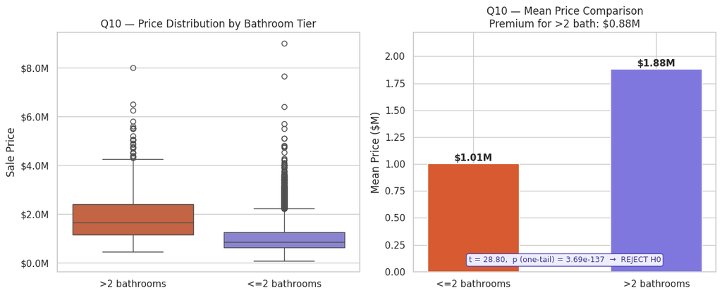

```python
fig, axes = plt.subplots(1, 2, figsize=(12, 5))

bath_df2 = df[['Price','Bathroom']].dropna().copy()
bath_df2['Tier'] = bath_df2['Bathroom'].apply(
    lambda x: '>2 bathrooms' if x > 2 else '<=2 bathrooms')

sns.boxplot(data=bath_df2, x='Tier', y='Price',
            order=['>2 bathrooms', '<=2 bathrooms'],
            palette=['#D85A30','#7F77DD'], ax=axes[0])
axes[0].yaxis.set_major_formatter(plt.FuncFormatter(lambda x, _: f'${x/1e6:.1f}M'))
axes[0].set_title('Q10 — Price Distribution by Bathroom Tier')
axes[0].set_xlabel('')
axes[0].set_ylabel('Sale Price')

means10 = bath_df2.groupby('Tier')['Price'].mean()
bars = axes[1].bar(means10.index, means10.values/1e6,
                   color=['#D85A30','#7F77DD'], edgecolor='white', width=0.5)
for i, (label, val) in enumerate(means10.items()):
    axes[1].text(i, val/1e6 + 0.02, f'${val/1e6:.2f}M', ha='center', fontsize=11, fontweight='bold')
premium = (means10['>2 bathrooms'] - means10['<=2 bathrooms']) / 1e6
axes[1].set_title(f'Q10 — Mean Price Comparison\nPremium for >2 bath: ${premium:.2f}M')
axes[1].set_ylabel('Mean Price ($M)')
axes[1].set_ylim(0, means10.max()/1e6 * 1.18)

from scipy.stats import ttest_ind
g1 = bath_df2[bath_df2['Tier']=='>2 bathrooms']['Price']
g2 = bath_df2[bath_df2['Tier']=='<=2 bathrooms']['Price']
t, p2 = ttest_ind(g1, g2, equal_var=False)
axes[1].text(0.5, 0.04, f't = {t:.2f},  p (one-tail) = {p2/2:.2e}  →  REJECT H0',
             transform=axes[1].transAxes, ha='center', fontsize=9,
             color='#3C3489',
             bbox=dict(boxstyle='round,pad=0.3', facecolor='#EEEDFE', edgecolor='#534AB7'))
plt.tight_layout()
plt.show()
```

```python
print("┌─ Q10 — Box Plot & Mean Comparison Bar Chart")
print("│  Left: price spread by bathroom tier. Right: >2 bath commands ~$875K premium over ≤2 bath (p << 0.05 → Reject H0).")
print("└─────────────────────────────────────────────────────────────────────")
```

```
┌─ Q10 — Box Plot & Mean Comparison Bar Chart
│  Left: price spread by bathroom tier. Right: >2 bath commands ~$875K premium over ≤2 bath (p << 0.05 → Reject H0).
└─────────────────────────────────────────────────────────────────────
```

Q10 Final Recommendation to Policymakers The one-tailed Welch two-sample t-test compares prices of properties with more than 2 bathrooms against properties with 2 or fewer bathrooms. If the reported p-value is below 0.05, the result is statistically significant and the null hypothesis should be rejected.

Recommendation: Policymakers should treat properties with more than 2 bathrooms as premium properties. Bathroom count can be used as an important pricing and housing-quality indicator when evaluating affordability, taxation, valuation, and housing policy decisions.